# Taller 03. R Markdown, Epiverse

03/09/2025

# 1. Introducción

En este taller aprenderemos sobre el uso del formato **R Markdown**, el cual permite integrar código en la generación de **informes** sin la necesidad de importar gráficas o crear tablas manualmente. De esta manera, el formato RMarkdown facilita la generación automática, actualización y redacción de informes técnicos al combinar la sintaxis del formato Markdown con código en R incrustado en el documento.

# 2. Objetivos

- Reconocer la importancia de generar informes en RMarkdown
- Aprender a utilizar Rmarkdown de forma básica

# 3. Tabla de contenido

- Tema 1: ¿Qué es R Markdown?
- Tema 2: Estructura de R Markdown
- Tema 3: Paso a Paso en R Markdown
- Tema 4: ¿Cómo editar el texto?
- Tema 5: ¿Cómo editar el chunk de código?
- Tema 6: Hacer tablas en R Markdown
- Tema 7: Poner parámetros automatizados en el texto
- Tema 8: Paso final - “Tejer” (generar) el informe

# 4. Temas

## Tema 1: ¿Qué es R Markdown?

*R Markdown* es una extensión del formato Markdown que permite combinar texto con código R incrustado en el documento. De esta manera, los análisis y visualizaciones generados por medio del código se pueden incorporar de manera natural en el texto.

*R Markdown* es ampliamente utilizado por científicos de datos, analistas, investigadores y profesionales que necesitan presentar sus análisis y resultados de manera clara y reproducible. Además, es una herramienta muy valiosa para generar informes automatizados y documentos técnicos interactivos

## Tema 2: Estructura de R Markdown

Un documento de **R Markdown** consta de tres tipos principales de elementos:

- **Yaml:** Corresponde a especificaciones del estilo del documento, título, fecha, autores, etc.
- **Texto**: Texto enriquecido con formato y explicaciones.
- **Chunk**: Bloque de código R en donde se ejecutan y se muestran sus resultados.

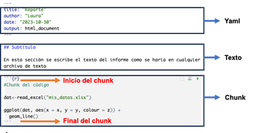

## Tema 3: Paso a Paso en R Markdown

### **Paso 1. Abrir R Studio desde R project**

De acuerdo a lo aprendido en la unidad de *Introducción a R y Rstudio*, es recomendable tener un R project donde quedará alojado el informe de R Markdown. Abre un R Project y sigue con el Paso 2.

### **Paso 2. Crear un nuevo archivo R Markdown**

Siguiendo la ruta **File>New File>R Markdown** podemos crear un archivo de R Markdown definiendo: título, autor(es) y con formato de salida preferido (html, pdf o word).

Sigue los pasos, que también pueden verse en la imagen, y crea tu archivo R Markdown con tu nombre y el título de Reporte.

[figure not shown]

### **Paso 3. Editar el archivo de R Markdown y el código**

Es importante recordar que R Markdown tiene tres secciones, todas editables: Yaml, Texto y Chunk de código.

Al haber creado tu archivo de R Markdown podrás observar e identificar las diferentes secciones que se muestran en la imagen.

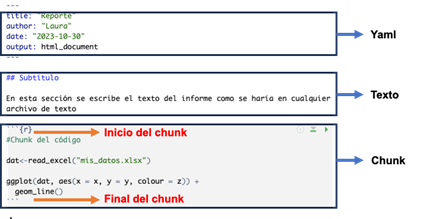